# mylab1

chenpeng

2024-07-01

# Lab1

## Part 1

### 1&2

```r
rates <- c(0.1, 0.5, 1, 5, 10)
exp.draws <- vector("list", length(rates))
means <- vector("numeric", length(rates))
sds <- vector("numeric", length(rates))

for (i in seq_along(rates)) {
  exp.draws[[i]] <- rexp(200, rate = rates[i])
  means[i] <- mean(exp.draws[[i]])
  sds[i] <- sd(exp.draws[[i]])

  cat("exp.draws.",rates[i],": mean = ",means[i],", ",sep="")
  cat("standard deviation = ",sds[i],"\n",sep="")

}
```

```
## exp.draws.0.1: mean = 8.529304, standard deviation = 7.695035
## exp.draws.0.5: mean = 1.925918, standard deviation = 1.715131
## exp.draws.1: mean = 1.049655, standard deviation = 0.9393331
## exp.draws.5: mean = 0.1845377, standard deviation = 0.1758824
## exp.draws.10: mean = 0.1099592, standard deviation = 0.129698
```

```r
exp.draws.0.1 <- exp.draws[[1]]
exp.draws.0.5 <- exp.draws[[2]]
exp.draws.1 <- exp.draws[[3]]
exp.draws.5 <- exp.draws[[4]]
exp.draws.10 <- exp.draws[[5]]
```

### 3

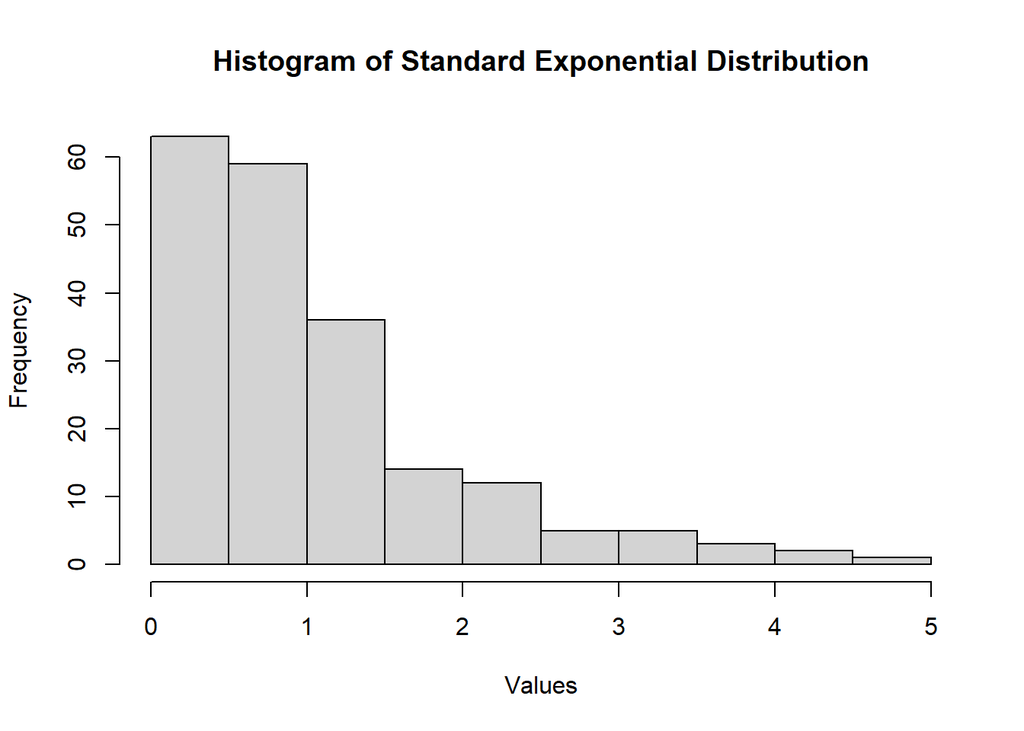

```r
# Assuming exp.draws.1 is already defined as the standard exponential distribution
hist(exp.draws.1, main = "Histogram of Standard Exponential Distribution", xlab = "Values")
```

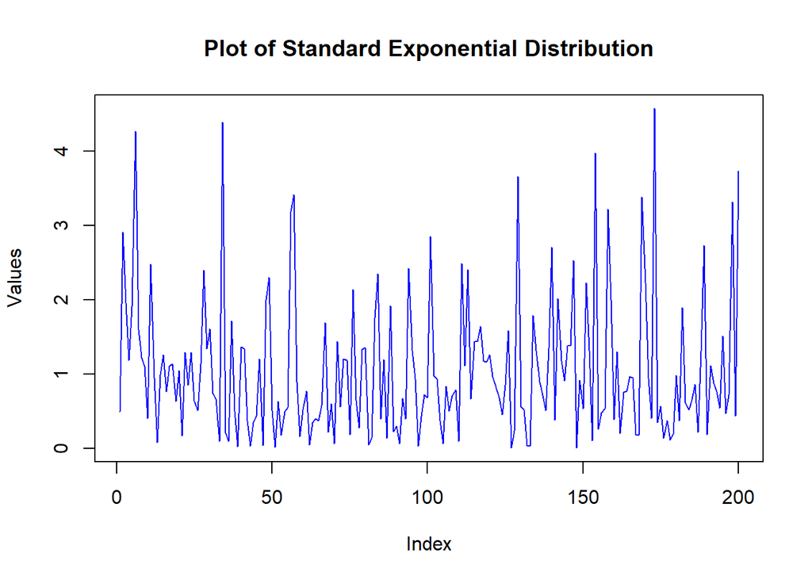

```r
# Plotting random values from standard exponential distribution
plot(exp.draws.1, type = "l", col = "blue", main = "Plot of Standard Exponential Distribution", xlab = "Index", ylab = "Values")
```

[figure not shown]

```r
# Plotting scatterplot of two random value vectors
plot(exp.draws[[1]], exp.draws[[3]], main = "Scatterplot of exp.draws.0.1 vs. exp.draws.5", xlab = "exp.draws.0.1", ylab = "exp.draws.5", col = "red", pch = 16)
```

Tip: pch determines the type of the point

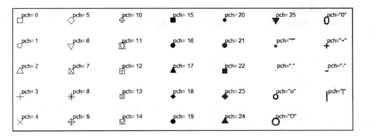

pch对应图

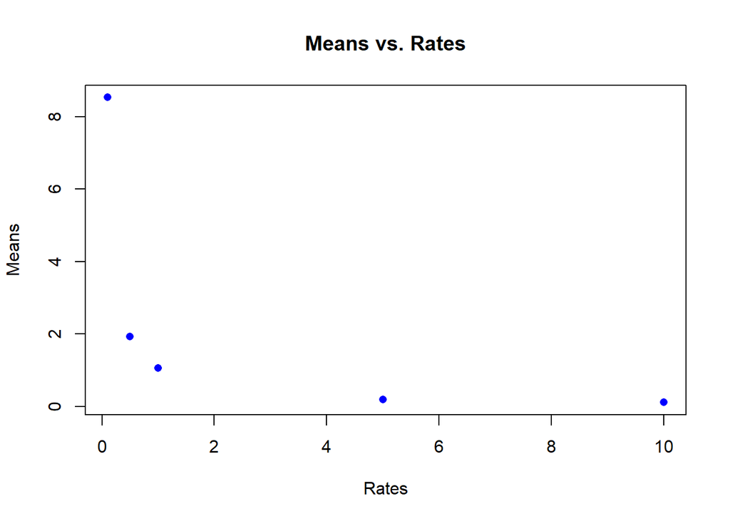

```r
# Scatterplots
# a. Means versus Rates
plot(rates, means, main = "Means vs. Rates", xlab = "Rates", ylab = "Means", col = "blue", pch = 16)
```

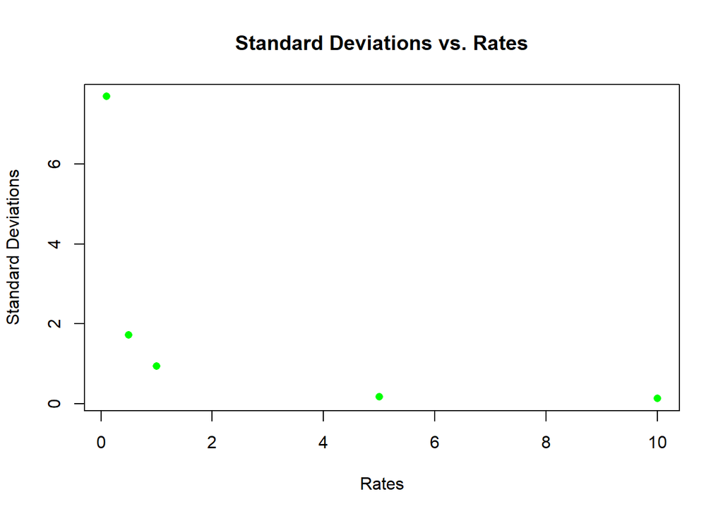

```r
# b. Standard Deviations versus Rates
plot(rates, sds, main = "Standard Deviations vs. Rates", xlab = "Rates", ylab = "Standard Deviations", col = "green", pch = 16)
```

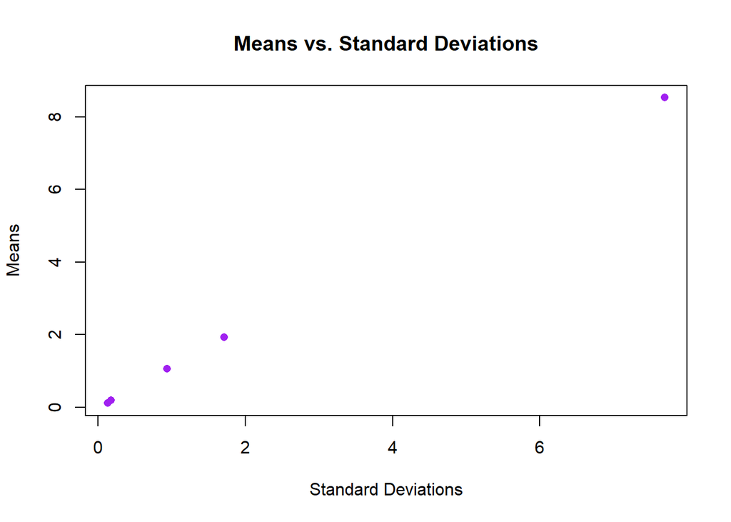

```r
# c. Means versus Standard Deviations
plot(sds, means, main = "Means vs. Standard Deviations", xlab = "Standard Deviations", ylab = "Means", col = "purple", pch = 16)
```

## Part 2

```r
big.exp.draws.1 <- rexp(1.1e6, rate = 1)
mean_big <- mean(big.exp.draws.1)
sd_big <- sd(big.exp.draws.1)
cat("big.exp.draws.1: mean = ", mean_big, ", standard deviation = ", sd_big,"\n",sep="")
```

```
## big.exp.draws.1: mean = 0.9990838, standard deviation = 0.9984803
```

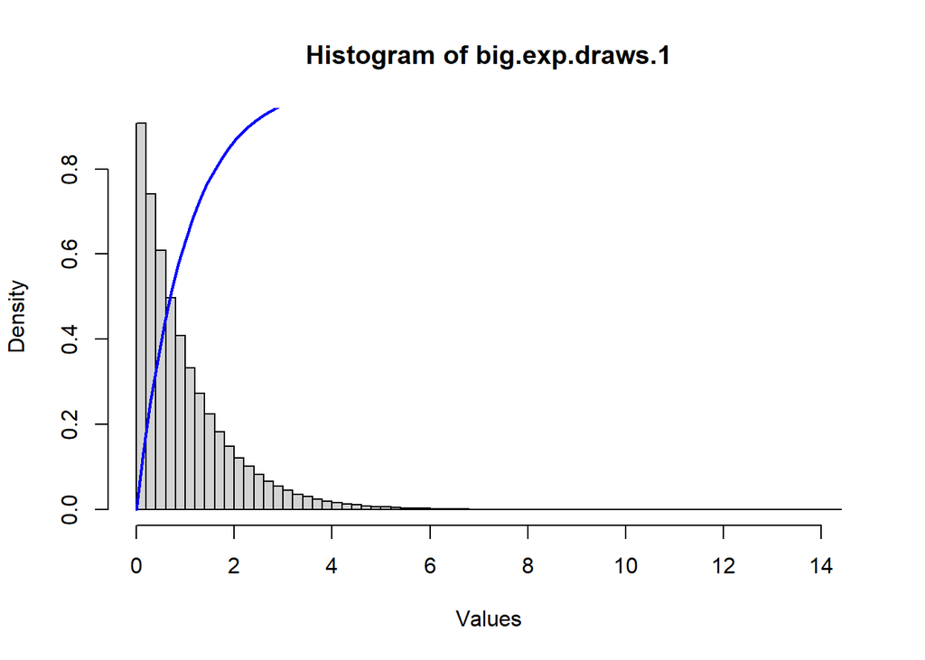

```r
# Plot histogram
hist(big.exp.draws.1, breaks = 100, freq = FALSE, main = "Histogram of big.exp.draws.1", xlab = "Values")

# Plot function 1 - exp(-x)
curve(1 - exp(-x), add = TRUE, col = "blue", lwd = 2)
```

Explanation for 5b):

```r
# Create vector of entries greater than 1
greater_than_1 <- big.exp.draws.1[big.exp.draws.1 > 1]

# Calculate mean
mean_greater_than_1 <- mean(greater_than_1)
mean_greater_than_1
```

```
## [1] 1.998446
```

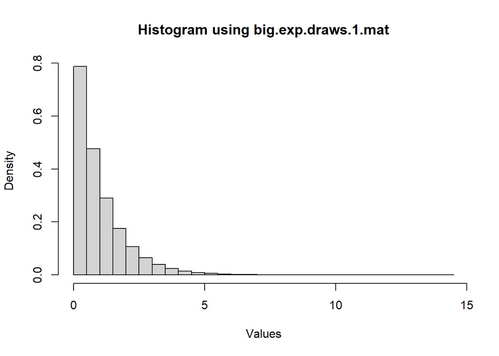

```r
# Create matrix with 1100 rows and 1000 columns
big.exp.draws.1.mat <- matrix(big.exp.draws.1, nrow = 1100, ncol = 1000)

# Histogram using hist() function
hist_result <- hist(big.exp.draws.1.mat, freq = FALSE, main = "Histogram using big.exp.draws.1.mat", xlab = "Values")
```

Explanation for 5d):

```r
# Calculate mean of the 371st column
mean_371st <- mean(big.exp.draws.1.mat[, 371])
mean_371st
```

```
## [1] 1.001679
```

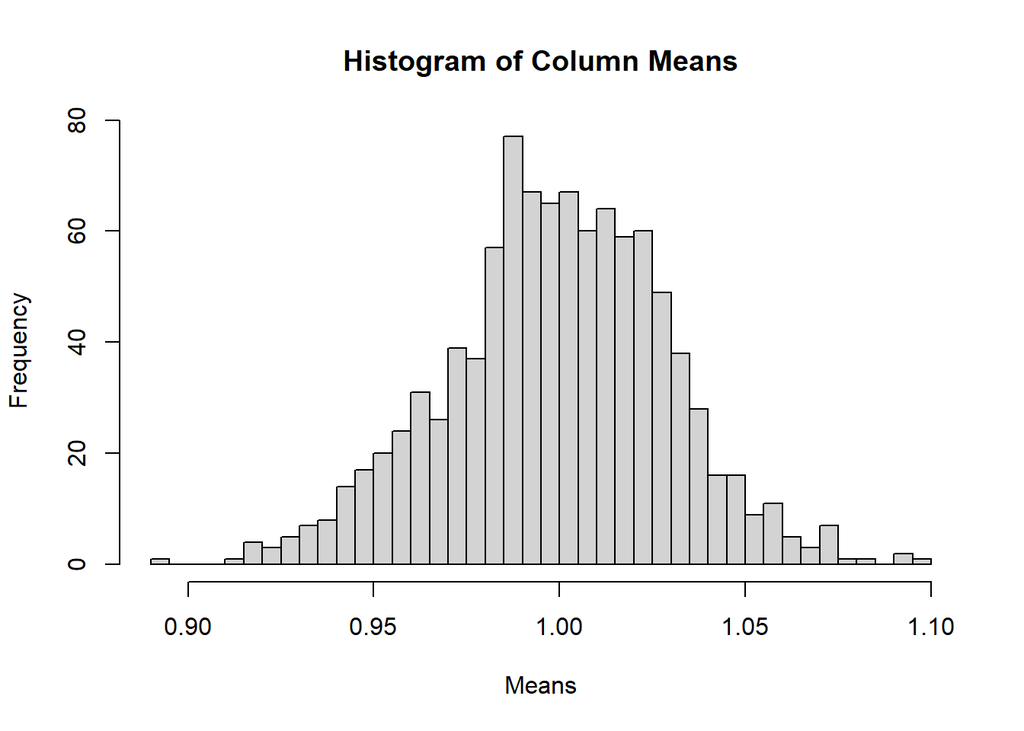

```r
# Calculate means of all columns
col_means <- colMeans(big.exp.draws.1.mat)

# Plot histogram of column means
hist(col_means, main = "Histogram of Column Means", xlab = "Means", breaks = 30)
```

Explanation for 5f):

The histogram of column means does not match the shape of the original histogram (problem 5b) because the distribution of means of many samples (columns) tends to approximate a normal distribution (by the Central Limit Theorem), whereas the original data (big.exp.draws.1) follows an exponential distribution.

```r
# Square each number in big.exp.draws.1
squared_values <- big.exp.draws.1^2

# Calculate mean of squared values
mean_squared <- mean(squared_values)
mean_squared
```

```
## [1] 1.99513
```

Explanation for 5g):

Taking the square of each number in big.exp.draws.1 affects both the mean and the standard deviation. Specifically, if ( X ) is exponentially distributed with mean ( $\mu$ ) and standard deviation ( $\sigma$ ), then ( X^2 ) has a mean of ( $\mu ^2 + \sigma ^2$ ). This results in an increase in the mean due to the squaring effect, while the standard deviation changes as per the mathematical properties of variance and standard deviation.